# Analysis: College Popularity by Google Trends

Chris Hales

2022-08-07

## Research Question

The College Scorecard was released at the start of September 2015. Among colleges that predominantly grant bachelor’s degrees, did the release of the Scorecard shift student interest to high-earnings colleges relative to low-earnings ones (as proxied by Google searches for keywords associated with those colleges)?

Or simply…

Was the effect of the Scorecard different between high and low earning colleges?

The null hypothesis is that the release of the scorecard did not have an effect on school search trends.

## Read in Data

Bring in the processed data and store it in the schools variable. Filter on predominately bachelor degree schools. View the data.

```r
schools = read_csv("./data_processed/weekly_trends_with_school_scorecards_2022_08_04.csv")
# Filter for colleges that primarily grant bachelors degrees. preddeg == 3.
schools = schools %>% filter(preddeg == 3)
vtable(schools)
```

schools

| Name | Class | Values |
| --- | --- | --- |
| schname | character |  |
| week | Date | Time: 2013-03-24 to 2016-03-27 |
| index_std | numeric | Num: -4.741 to 10.452 |
| unitid | numeric | Num: 100654 to 475273 |
| opeid | numeric | Num: 100200 to 82098821 |
| opeid6 | numeric | Num: 1002 to 40513 |
| instnm | character |  |
| city | character |  |
| stabbr | character |  |
| insturl | character |  |
| npcurl | character |  |
| hcm2 | numeric | Num: 0 to 1 |
| preddeg | numeric | Num: 3 to 3 |
| control | numeric | Num: 1 to 3 |
| locale | numeric | Num: 11 to 43 |
| hbcu | numeric | Num: 0 to 1 |
| pbi | numeric | Num: 0 to 1 |
| annhi | numeric | Num: 0 to 1 |
| tribal | numeric | Num: 0 to 1 |
| aanapii | numeric | Num: 0 to 1 |
| hsi | numeric | Num: 0 to 1 |
| nanti | numeric | Num: 0 to 1 |
| menonly | numeric | Num: 0 to 1 |
| womenonly | numeric | Num: 0 to 1 |
| relaffil | character |  |
| satvr25 | character |  |
| satvr75 | character |  |
| satmt25 | character |  |
| satmt75 | character |  |
| satwr25 | character |  |

[output cut: 96 more lines]

## Data Check: The Dependent Variable

Scatterplot of the dependent variable, index_std:

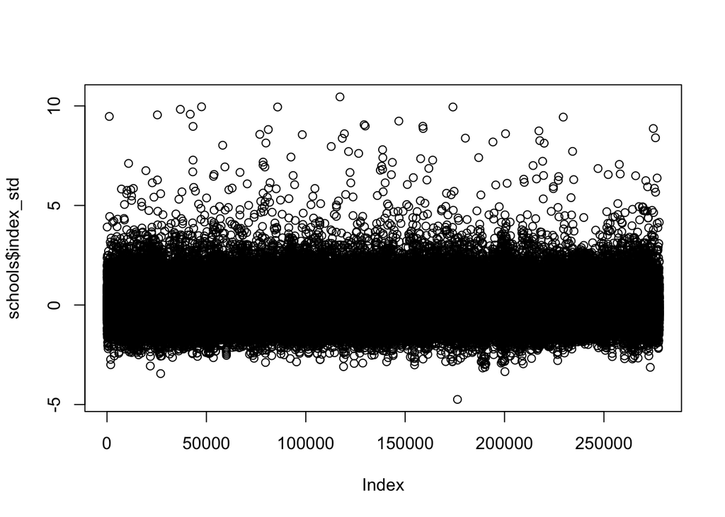

```r
plot(schools$index_std)
```

The dependent variable, index_std, was standardized across school names and search keywords in the data prep script. Based on the above graph it looks like index_std is appropriately standardized. No further work is needed.

## Seasonality

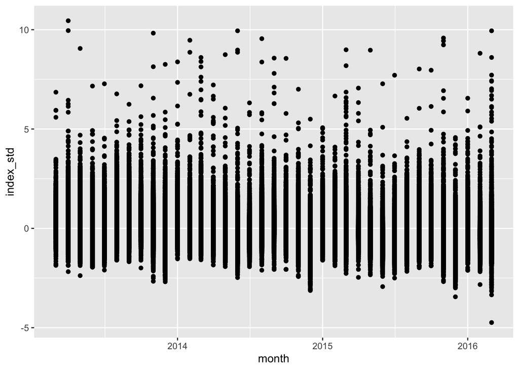

```r
ggplot(schools, aes(x = month, y = index_std)) + geom_point()
```

There does appear to be some seasonal changes within a year that repeat from year to year. Which would make sense with changes over time in the school term and when people would be applying for colleges. I’ll solve for that with a month variable inside i(). Here we build out the month_digit variable and factor it as months can be defined as categorical in nature.

```r
schools = schools %>% mutate(month_digit = factor(month(week)))
vtable(schools)
```

schools

| Name | Class | Values |
| --- | --- | --- |
| schname | character |  |
| week | Date | Time: 2013-03-24 to 2016-03-27 |
| index_std | numeric | Num: -4.741 to 10.452 |
| unitid | numeric | Num: 100654 to 475273 |
| opeid | numeric | Num: 100200 to 82098821 |
| opeid6 | numeric | Num: 1002 to 40513 |
| instnm | character |  |
| city | character |  |
| stabbr | character |  |
| insturl | character |  |
| npcurl | character |  |
| hcm2 | numeric | Num: 0 to 1 |
| preddeg | numeric | Num: 3 to 3 |
| control | numeric | Num: 1 to 3 |
| locale | numeric | Num: 11 to 43 |
| hbcu | numeric | Num: 0 to 1 |
| pbi | numeric | Num: 0 to 1 |
| annhi | numeric | Num: 0 to 1 |
| tribal | numeric | Num: 0 to 1 |
| aanapii | numeric | Num: 0 to 1 |
| hsi | numeric | Num: 0 to 1 |
| nanti | numeric | Num: 0 to 1 |
| menonly | numeric | Num: 0 to 1 |
| womenonly | numeric | Num: 0 to 1 |
| relaffil | character |  |
| satvr25 | character |  |
| satvr75 | character |  |
| satmt25 | character |  |
| satmt75 | character |  |
| satwr25 | character |  |

[output cut: 97 more lines]

## Factor Unitid

Here I will need to control for within variation for the different schools. Since there is panel data with respect to the various different schools we will need to control for that via the unique id for each university. This will help control the variation within the schools.

```r
schools = schools %>% mutate(unitid = factor(unitid))
```

## Earnings, the Interaction Variable.

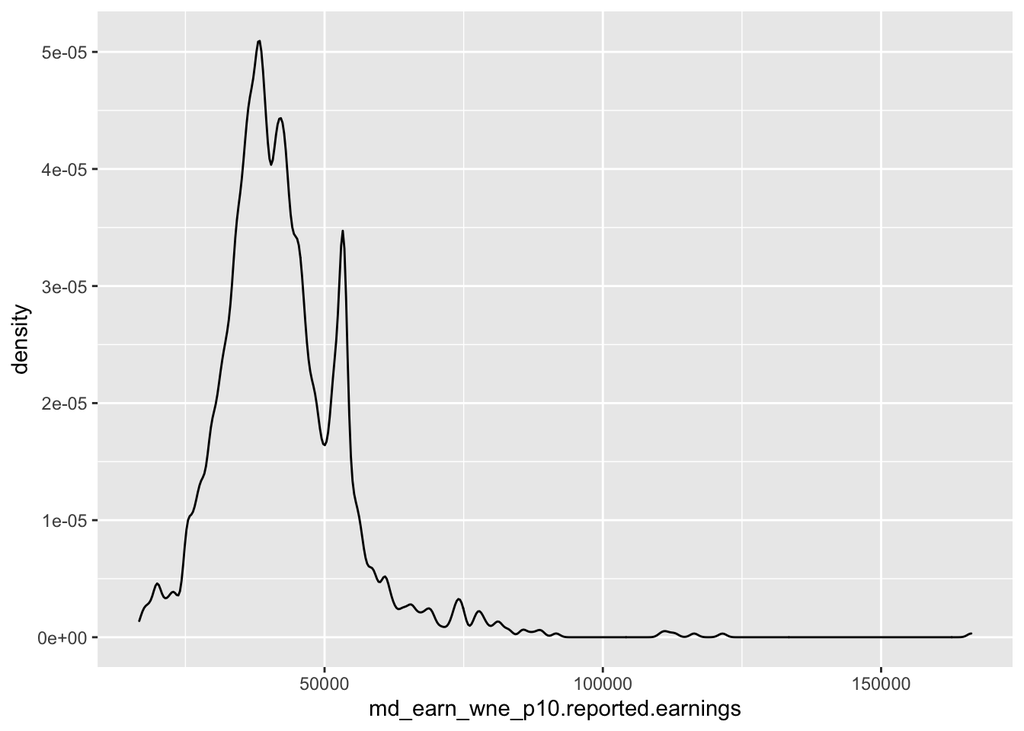

```r
ggplot(schools, aes(x = md_earn_wne_p10.reported.earnings)) + geom_density()
```

Since I am not going to use the actual earnings within the regression we do not need to take the log of this skewed variable. I will use earnings to decide if a given school is a high or low earning school creating a binary variable.

```r
summary(as.numeric(schools$md_earn_wne_p10.reported.earnings))
```

```
##    Min. 1st Qu.  Median    Mean 3rd Qu.    Max.
##   16700   35500   40900   42466   48100  166200
```

```r
schools = schools %>% mutate(is_high_income = case_when(md_earn_wne_p10.reported.earnings > 48100 ~ TRUE, md_earn_wne_p10.reported.earnings <= 48100 ~ FALSE))

summary(as.numeric(schools$is_high_income))
```

```
##    Min. 1st Qu.  Median    Mean 3rd Qu.    Max.
##   0.000   0.000   0.000   0.249   0.000   1.000
```

## The Independent Variable.

The exact date for the release was 2015-09-12 according to the [naicu](https://www.naicu.edu/policy-advocacy/issue-brief-index/regulation/college-scorecard#:~:text=About,a%20federal%20postsecondary%20ratings%20system). This should allow us to split the data into a pre and post scorecard and then check the differences in the interaction effects of the binary is_high_income variable.

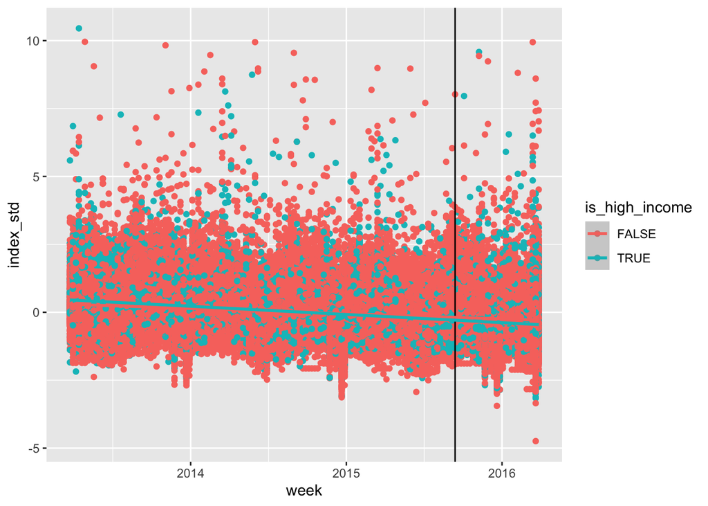

```r
schools_bin = schools %>% mutate(is_scorecard =
                                   case_when(week <= ymd("2015-09-13") ~ FALSE,
                                             week > ymd("2015-09-13") ~ TRUE))

ggplot(schools_bin, aes(x = week, y = index_std, color = is_high_income)) + geom_point() + geom_vline(xintercept = as.Date("2015-09-13")) + geom_smooth(method = 'lm')
```

## Regression

```r
reg_bin = feols(schools_bin, index_std ~ is_scorecard + is_high_income + is_scorecard*is_high_income + i(month_digit) | unitid )
```

```
## The variable 'is_high_incomeTRUE' has been removed because of collinearity (see $collin.var).
```

```r
etable(reg_bin, keep=c("is_scorecard", "is_high_income"))
```

```
##                                                   reg_bin
## Dependent Var.:                                 index_std
##
## is_scorecardTRUE                      -0.3015*** (0.0097)
## is_scorecardTRUE x is_high_incomeTRUE -0.1381*** (0.0270)
## Fixed-Effects:                        -------------------
## unitid                                                Yes
## _____________________________________ ___________________
## S.E.: Clustered                                by: unitid
## Observations                                      277,909
## R2                                                0.16398
## Within R2                                         0.16398
## ---
## Signif. codes: 0 '***' 0.001 '**' 0.01 '*' 0.05 '.' 0.1 ' ' 1
```

Checking for heteroskedasticity

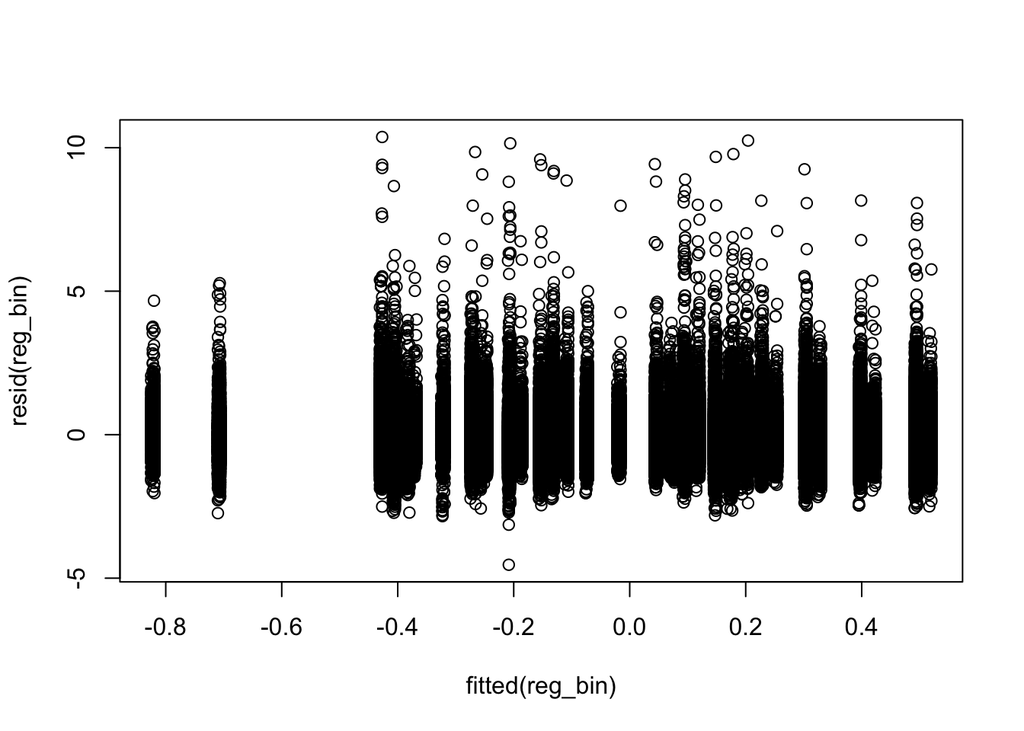

```r
plot(fitted(reg_bin), resid(reg_bin))
```

There does appear to be an issue with heteroskedasticity as the residuals are a little more wide towards the center and right of the graph and there is a pattern with the data.

```r
reg_bin = feols(schools_bin, index_std ~ is_scorecard + is_high_income + is_scorecard*is_high_income + i(month_digit) | unitid, vcov = "hetero" )
```

```
## The variable 'is_high_incomeTRUE' has been removed because of collinearity (see $collin.var).
```

```r
etable(reg_bin, keep=c("is_scorecard", "is_high_income"))
```

```
##                                                   reg_bin
## Dependent Var.:                                 index_std
##
## is_scorecardTRUE                      -0.3015*** (0.0043)
## is_scorecardTRUE x is_high_incomeTRUE -0.1381*** (0.0083)
## Fixed-Effects:                        -------------------
## unitid                                                Yes
## _____________________________________ ___________________
## S.E. type                             Heteroskedast.-rob.
## Observations                                      277,909
## R2                                                0.16398
## Within R2                                         0.16398
## ---
## Signif. codes: 0 '***' 0.001 '**' 0.01 '*' 0.05 '.' 0.1 ' ' 1
```

```r
wald(reg_bin, c("is_scorecard", "is_high_income"), vcov = "hetero")
```

```
## Wald test, H0: joint nullity of is_scorecardTRUE and is_scorecardTRUE:is_high_incomeTRUE
##  stat = 3,943.3, p-value < 2.2e-16, on 2 and 276,117 DoF, VCOV: Heteroskedasticity-robust.
```

Seems that the p-value is low enough to reject that null hypothesis that is_scorecard has no effect on Google trends relative to the individual schools. More on this in the next section.

## Regression Analysis

Controlling for the individual school characteristics and the month, when the scorecard exists low income schools have an average index of 0.1381 higher than high income schools that is statistically significant at the 99.9% confidence level. A lower R2 means that there are a lot of this relationship that we fail to cover with this regression. This finding does run counter to what my initial belief in that I assumed the opposite would be true.